# PeerAssignment1

# Loading and preprocessing the data

#### Loading

```r
  setwd('/Users/ohjimin/Documents/R study')
  data<-read.csv('activity.csv')
```

#### Preprocessing

```r
  library(ggplot2)
  library(dplyr)
  head(data)
```

```
##   steps       date interval
## 1    NA 2012-10-01        0
## 2    NA 2012-10-01        5
## 3    NA 2012-10-01       10
## 4    NA 2012-10-01       15
## 5    NA 2012-10-01       20
## 6    NA 2012-10-01       25
```

```r
  str(data)
```

```
## 'data.frame':    17568 obs. of  3 variables:
##  $ steps   : int  NA NA NA NA NA NA NA NA NA NA ...
##  $ date    : Factor w/ 61 levels "2012-10-01","2012-10-02",..: 1 1 1 1 1 1 1 1 1 1 ...
##  $ interval: int  0 5 10 15 20 25 30 35 40 45 ...
```

```r
  summary(data)
```

```
##      steps                date          interval
##  Min.   :  0.00   2012-10-01:  288   Min.   :   0.0
##  1st Qu.:  0.00   2012-10-02:  288   1st Qu.: 588.8
##  Median :  0.00   2012-10-03:  288   Median :1177.5
##  Mean   : 37.38   2012-10-04:  288   Mean   :1177.5
##  3rd Qu.: 12.00   2012-10-05:  288   3rd Qu.:1766.2
##  Max.   :806.00   2012-10-06:  288   Max.   :2355.0
##  NA's   :2304     (Other)   :15840
```

```r
  data$date <- as.Date(data$date)
```

# What is mean total number of steps taken per day?

#### Calculate the total number of steps taken per day

```r
  total_step <- tapply(data$steps, data$date, sum, na.rm=FALSE)
```

#### Make histogram of total number of steps taken each day

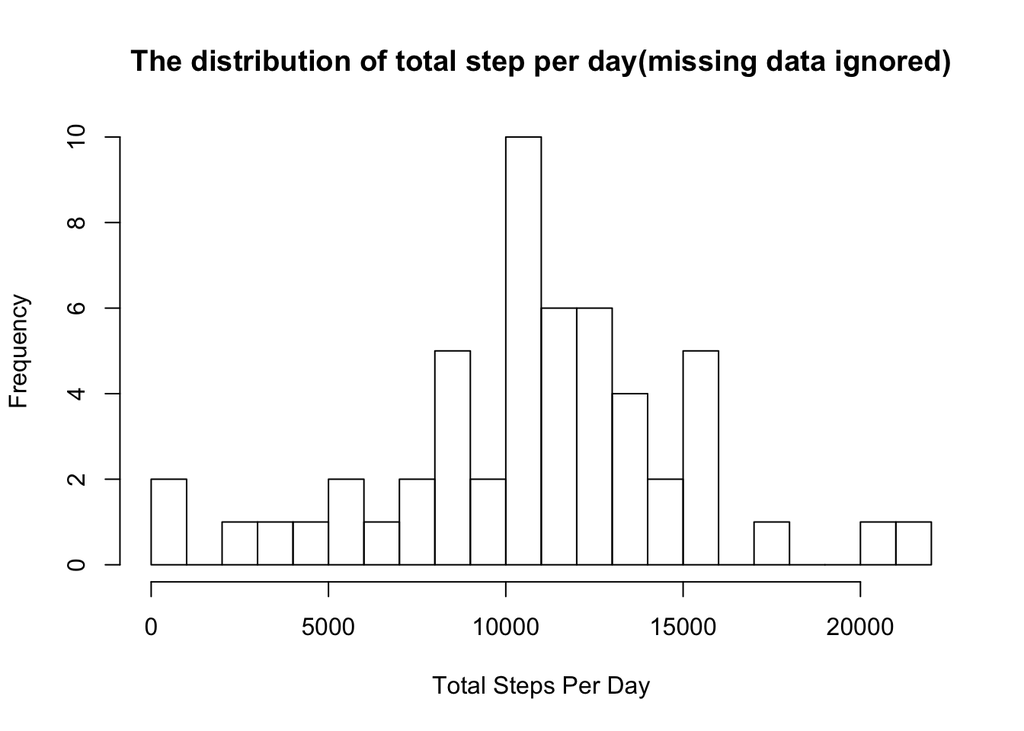

```r
  hist(x=total_step,breaks=20,xlab="Total Steps Per Day", ylab="Frequency", main="The distribution of total step per day(missing data ignored)")
```

#### Calculate and report the mean and median of the total number of steps taken per day.

```r
  total_step_na <- total_step[!is.na(total_step)]
    mean(total_step_na)
```

```
## [1] 10766.19
```

```r
    median(total_step_na)
```

```
## [1] 10765
```

# What is the average daily activity pattern?

#### Activity pattern

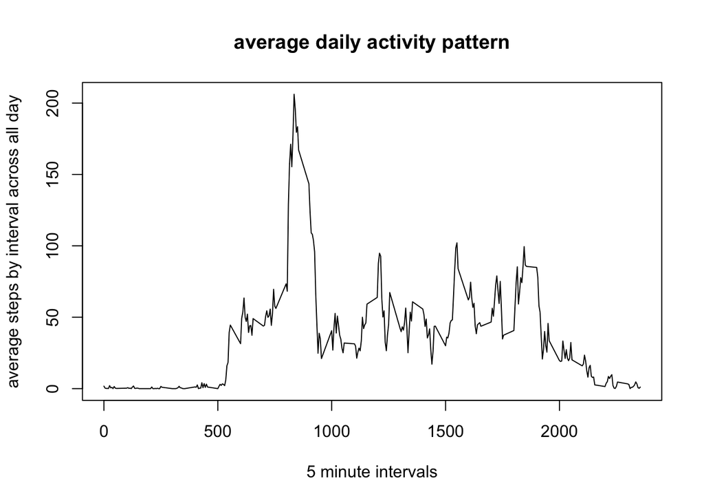

```r
  interval_avg <- tapply(data$steps, data$interval, mean, na.rm=TRUE)
  interval_int <- data.frame(interval=as.integer(names(interval_avg)), avg=interval_avg)
  with(interval_int, plot(interval, avg,type="l", xlab="5 minute intervals", ylab="average steps by interval across all day", main="average daily activity pattern"))
```

#### Maximum number of steps

```r
  max <- max(interval_int$avg)
  interval_int[interval_int$avg== max,]
```

```
##     interval      avg
## 835      835 206.1698
```

# Imputing missing values

#### Calculate and report the total number of missing values in the dataset

```r
  sum(is.na(data$steps))
```

```
## [1] 2304
```

It is 2304 NAs

#### Devise a strategy for filling in all of the missing values in the dataset.

```r
  data_impute <- data
  nano<- is.na(data_impute$steps)
  interval_avg <- tapply(data$steps, data$interval, mean, na.rm=TRUE)
  data_impute$steps[nano] <- interval_avg[as.character(data_impute$interval[nano])]
```

#### Make a histogram of the total number of steps taken each day and Calculate and report the mean and median total number of steps taken per day.

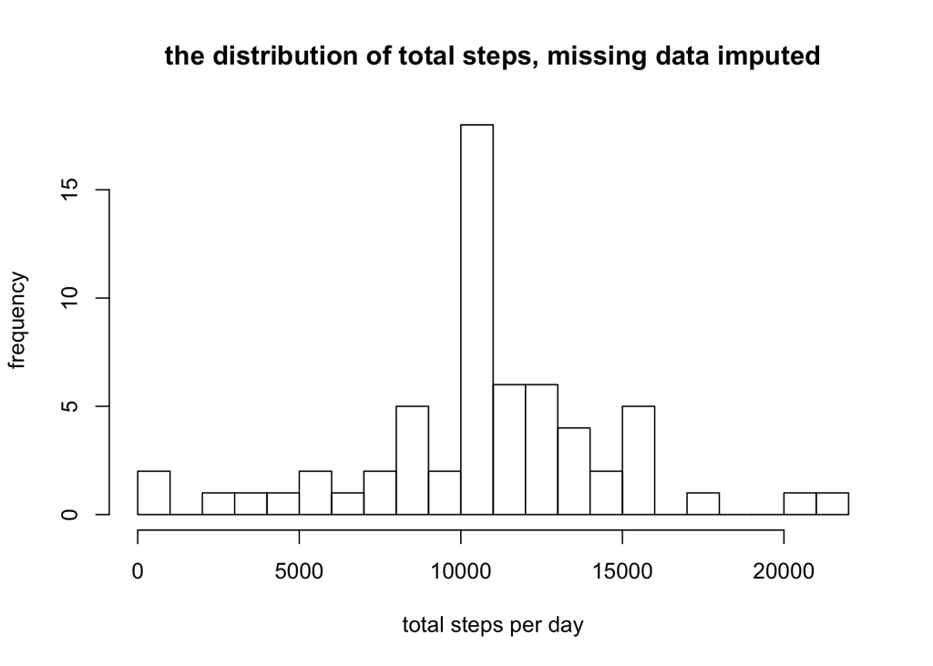

```r
  new_total <- tapply(data_impute$steps, data_impute$date, sum, na.rm=TRUE)
  hist(x=new_total, breaks=20, xlab="total steps per day", ylab="frequency", main="the distribution of total steps, missing data imputed")
```

#### mean and median

```r
  mean(new_total)
```

```
## [1] 10766.19
```

```r
  median(new_total)
```

```
## [1] 10766.19
```

# Are there differences in activity patterns between weekdays and weekends?

#### Create a new factor variable in the dataset with two levels; weekday, weekend. It is indicating whether a given date is a weekday or weekend day.

```r
  data_impute$date <- as.Date(data_impute$date)
  weekday <- ifelse(weekdays(data_impute$date) %in% c("Saturday", "Sunday"), "weekend", "weekday")
  weekday <- as.factor(weekday)
  data_impute$weekday <- weekday
```

#### Make a panel plot containing a time series plot of the 5-minute interval and the average number of steps taken, averaged across all weekday days or weekend days.

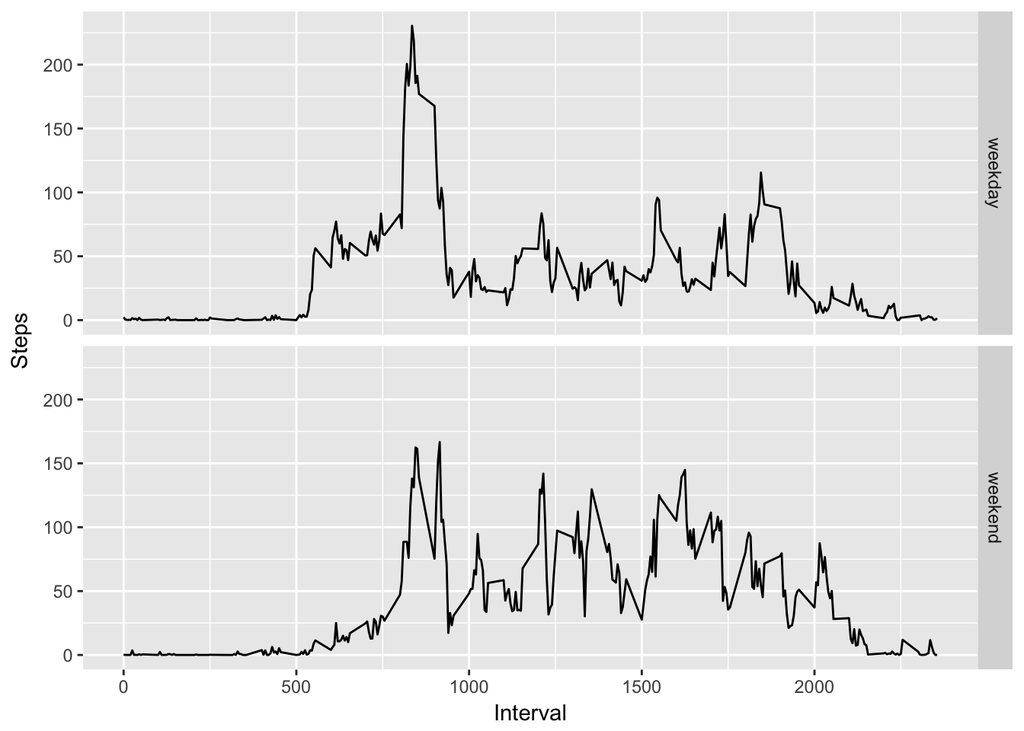

```r
  average_weekday <- group_by(data_impute,weekday,interval) %>% summarise(average_steps=mean(steps))
  g <- ggplot(average_weekday, aes(x=interval, y=average_steps)) + geom_line() + facet_grid(weekday~.) + labs(x="Interval") + labs(y="Steps")
  g
```